# Model-based recursive Partitioning

Malte Schierholz

5 Feb 2018

## Setup

```r
library("partykit")
library("Formula")
library("vcd") # for visualization
library("sandwich") # to demonstrate parameter instability test
```

## Data

Journal prices have received some interest in the economic literature (see http://econ.ucsb.edu/~tedb/Journals/jpricing.html)

In the following I replicate in large parts an analysis from Zeileis, Hothorn and Hornik (2008) (see https://cran.r-project.org/web/packages/partykit/vignettes/mob.pdf)

- Unit of Observation: 180 economic journals
- Dependent variable: Demand = log(number of US library subscriptions)

```r
data("Journals", package = "AER")
Journals <- transform(Journals, age = 2000 - foundingyear, chars = charpp * pages)
head(Journals)
```

```
##                                                      title
## APEL                     Asian-Pacific Economic Literature
## SAJoEH           South African Journal of Economic History
## CE                                 Computational Economics
## MEPiTE MOCT-MOST Economic Policy in Transitional Economics
## JoSE                            Journal of Socio-Economics
## LabEc                                     Labour Economics
##                     publisher society price pages charpp citations
## APEL                Blackwell      no   123   440   3822        21
## SAJoEH So Afr ec history assn      no    20   309   1782        22
## CE                     Kluwer      no   443   567   2924        22
## MEPiTE                 Kluwer      no   276   520   3234        22
## JoSE                 Elsevier      no   295   791   3024        24
## LabEc                Elsevier      no   344   609   2967        24
##        foundingyear subs             field age   chars
## APEL           1986   14           General  14 1681680
## SAJoEH         1986   59  Economic History  14  550638
## CE             1987   17       Specialized  13 1657908
## MEPiTE         1991    2      Area Studies   9 1681680
## JoSE           1972   96 Interdisciplinary  28 2391984
## LabEc          1994   15             Labor   6 1806903
```

## Estimate trees

Estimate a regression tree

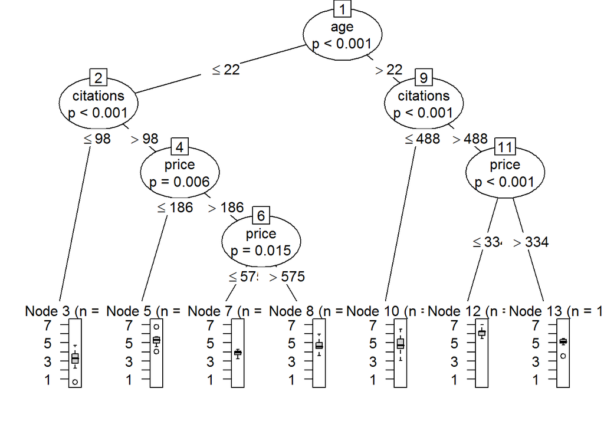

```r
tree1 <- lmtree(log(subs) ~ 1 | price + citations + age + chars + society, data = Journals)
plot(tree1)
```

A good regression model is already known to be: $\log \text{subscriptions} = \beta_0 + \beta_1 \log \frac{\text{price}}{\text{citations}} + \epsilon$ (OLS model from Stock and Watson)

Though, the authors who developed this regression model also suspect that age, number of characters, and its interactions with price and citations may improve the model.

We have three types of variables:

- response variable ($\log \text{subscriptions}$, based on economic knowledge)
- predictor variables ($\log \frac{\text{price}}{\text{citations}}$, based on economic knowledge)
- partitioning variables (relationship unclear)

Do the parameters $\beta_0$ and $\beta_1$ depend on the partitioning variables?

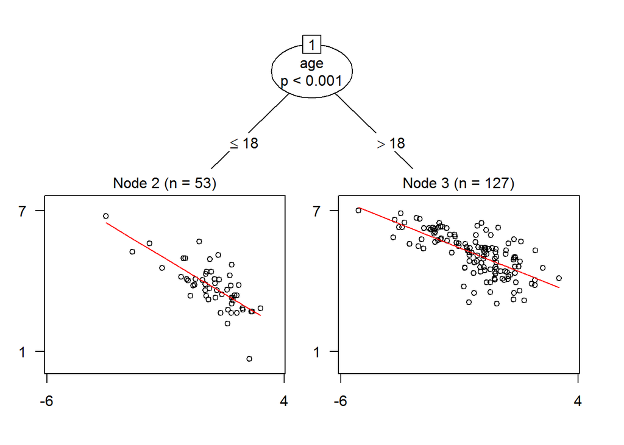

```r
tree2 <- lmtree(log(subs) ~ log(price/citations) | price + citations + age + chars + society, data = Journals)
plot(tree2)
```

## What is happening?

Build the same tree again with option verbose = TRUE to see information about the fitting process

```r
tree2 <- lmtree(log(subs) ~ log(price/citations) | price + citations + age + chars + society, data = Journals, verbose = TRUE)
```

```
##
## -- Node 1 ---------------------------------
## Number of observations: 180
##
## Parameter instability tests:
##               price citations          age     chars   society
## statistic 6.5617160 3.7647068 4.219816e+01 4.5638410 3.2797248
## p.value   0.9121766 0.9998028 1.625913e-07 0.9969504 0.6598605
##
## Best splitting variable: age
## Perform split? yes
## Selected split: <= 18 | > 18
##
## -- Node 2 ---------------------------------
## Number of observations: 53
##
## Parameter instability tests:
##              price citations       age     chars   society
## statistic 3.341523  2.169680 5.1667933 2.9019336 0.6495396
## p.value   0.975995  0.999083 0.7978025 0.9905272 0.9983602
##
## Best splitting variable: age
## Perform split? no
##
## -- Node 3 ---------------------------------
## Number of observations: 127
##
## Parameter instability tests:
##              price citations       age    chars   society
## statistic 2.039284 5.0765882 5.9867718 3.676880 0.6083476
## p.value   1.000000 0.9788821 0.9259707 0.999388 0.9987591
##
## Best splitting variable: age
## Perform split? no
```

```r
# an alternative to verbose = TRUE
# library(strucchange) ## just for sctest
# sctest(tree2, node = 1)
```

Tree growing proceeds in three iterated steps:

1. A model $\log \text{subscriptions} = \beta_0 + \beta_1 \log \frac{\text{price}}{\text{citations}} + \epsilon$ was fitted on the complete dataset.
2. Parameter instability tests are then performed to test the null hypothesis if $\beta_0$ and $\beta_1$ are constant over the partitioning variable $Z_1$. This is repeated for every variable $Z_j$. (see below for details)
3. Since age has minimal p.value, the next split will be on age. An exhaustive search over all possible thresholds in age is performed. For each possible splitting point, two models are estimated, the residual sums of squares from both models are summed up, and the splitting point having the smallest residual sum of squares is selected. We split on age $\leq 18$.

Residual sum of squares is the criterion in lmtree, but other objective functions are used for other models with non-metric outcomes.

The same procedure is repeated within each child node, but no significant parameter instabilities (significance level $\alpha < 0.05$) are found. The tree building process stops.

## Get more information about the models at each node

We can extract any node from the tree

```r
tree2[3] # node No. 3
```

```
## Linear model tree
##
## Model formula:
## log(subs) ~ log(price/citations) | price + citations + age +
##     chars + society
##
## Fitted party:
## [3] root: n = 127
##              (Intercept) log(price/citations)
##                5.0112687           -0.4029761
##
## Number of inner nodes:    0
## Number of terminal nodes: 1
## Number of parameters per node: 2
## Objective function (residual sum of squares): 54.28065
```

Or get information about just a single node

```r
print(tree2, node = 3)
```

```
## Linear model tree
## -- Node 3 --
##
## Estimated parameters:
##          (Intercept) log(price/citations)
##            5.0112687           -0.4029761
##
## Objective function:
## 54.28065
##
## Parameter instability tests:
##              price citations       age    chars   society
## statistic 2.039284 5.0765882 5.9867718 3.676880 0.6083476
## p.value   1.000000 0.9788821 0.9259707 0.999388 0.9987591
```

Model summary at nodes 1 to 3

```r
summary(tree2, node = 1:3)
```

```
## $`1`
##
## Call:
## lm(formula = log(subs) ~ log(price/citations))
##
## Residuals:
##      Min       1Q   Median       3Q      Max
## -2.72478 -0.53609  0.03721  0.46619  1.84808
##
## Coefficients:
##                      Estimate Std. Error t value Pr(>|t|)
## (Intercept)           4.76621    0.05591   85.25   <2e-16 ***
## log(price/citations) -0.53305    0.03561  -14.97   <2e-16 ***
## ---
## Signif. codes:  0 '***' 0.001 '**' 0.01 '*' 0.05 '.' 0.1 ' ' 1
##
## Residual standard error: 0.7497 on 178 degrees of freedom
## Multiple R-squared:  0.5573, Adjusted R-squared:  0.5548
## F-statistic:   224 on 1 and 178 DF,  p-value: < 2.2e-16
##
##
## $`2`
##
## Call:
## lm(formula = log(subs) ~ log(price/citations))
##
## Residuals:
##      Min       1Q   Median       3Q      Max
## -2.12974 -0.37882 -0.05063  0.35693  1.57877
##
## Coefficients:
##                      Estimate Std. Error t value Pr(>|t|)
## (Intercept)           4.35278    0.11687  37.244  < 2e-16 ***
## log(price/citations) -0.60486    0.07483  -8.083 1.08e-10 ***
## ---
## Signif. codes:  0 '***' 0.001 '**' 0.01 '*' 0.05 '.' 0.1 ' ' 1
##
## Residual standard error: 0.6682 on 51 degrees of freedom
## Multiple R-squared:  0.5616, Adjusted R-squared:  0.553
## F-statistic: 65.34 on 1 and 51 DF,  p-value: 1.078e-10
##
##
## $`3`
##
## Call:
## lm(formula = log(subs) ~ log(price/citations))
##
## Residuals:
##      Min       1Q   Median       3Q      Max
## -2.16039 -0.38995  0.08398  0.41365  1.52063
##
## Coefficients:
##                      Estimate Std. Error t value Pr(>|t|)
## (Intercept)           5.01127    0.05985   83.74   <2e-16 ***
## log(price/citations) -0.40298    0.03804  -10.59   <2e-16 ***
## ---
## Signif. codes:  0 '***' 0.001 '**' 0.01 '*' 0.05 '.' 0.1 ' ' 1
##
## Residual standard error: 0.659 on 125 degrees of freedom
## Multiple R-squared:  0.4731, Adjusted R-squared:  0.4689
## F-statistic: 112.2 on 1 and 125 DF,  p-value: < 2.2e-16
```

Model coefficients at nodes 2 and 3

```r
coef(tree2, node = c(2, 3))
```

```
##   (Intercept) log(price/citations)
## 2    4.352781           -0.6048551
## 3    5.011269           -0.4029761
```

Extract log-Likehood and Information Criteria

```r
logLik(tree2)
```

```
## 'log Lik.' -179.0479 (df=7)
```

```r
AIC(tree2)
```

```
## [1] 372.0958
```

```r
BIC(tree2)
```

```
## [1] 394.4465
```

## How to make predictions?

We can either predict the leaf of the tree or the final response

```r
(J_new <- head(Journals, 5)) # select first five entries from dataset
```

```
##                                                      title
## APEL                     Asian-Pacific Economic Literature
## SAJoEH           South African Journal of Economic History
## CE                                 Computational Economics
## MEPiTE MOCT-MOST Economic Policy in Transitional Economics
## JoSE                            Journal of Socio-Economics
##                     publisher society price pages charpp citations
## APEL                Blackwell      no   123   440   3822        21
## SAJoEH So Afr ec history assn      no    20   309   1782        22
## CE                     Kluwer      no   443   567   2924        22
## MEPiTE                 Kluwer      no   276   520   3234        22
## JoSE                 Elsevier      no   295   791   3024        24
##        foundingyear subs             field age   chars
## APEL           1986   14           General  14 1681680
## SAJoEH         1986   59  Economic History  14  550638
## CE             1987   17       Specialized  13 1657908
## MEPiTE         1991    2      Area Studies   9 1681680
## JoSE           1972   96 Interdisciplinary  28 2391984
```

```r
predict(tree2, newdata = J_new, type = "node")
```

```
##   APEL SAJoEH     CE MEPiTE   JoSE
##      2      2      2      2      3
```

```r
predict(tree2, newdata = J_new, type = "response")
```

```
##     APEL   SAJoEH       CE   MEPiTE     JoSE
## 3.283602 4.410430 2.536687 2.822886 4.000233
```

## How to control overfitting?

Overfitting can be controlled with

- alpha (default significance level = 0.05),
- minsize, or
- maxdepth.

For large sample sizes, p-values will always be small. One may need to decrease alpha or use post-pruning (based on AIC or BIC, or …).

Our sample is with 180 journals quite small. We incresase $\alpha$ in the following so that the tree grows larger (and might overfit the data).

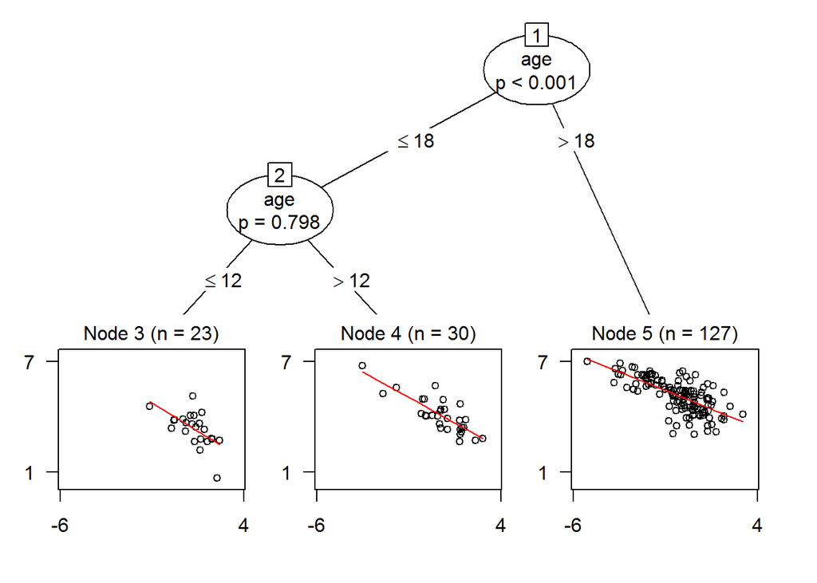

```r
tree3 <- lmtree(log(subs) ~ log(price/citations) | price + citations + age + chars + society,
                data = Journals,
                alpha = 0.85, # default significance level = 0.05
                minsize = NULL, # default: min. (10*no. of parameters) observations per node
                maxdepth = Inf # default: Infinity
                )
plot(tree3)
```

Lets have a look at the AIC from both trees.

```r
AIC(tree2)
```

```
## [1] 372.0958
```

```r
AIC(tree3)
```

```
## [1] 372.3067
```

The tree with two leaves we grew earlier has smaller AIC and should thus be preferred, according to the AIC criterion.

We can select the better tree automatically. We now set the option prune = “AIC”. This means we build the full tree as above, but then we prune back the tree to the subtree having the smallest AIC.

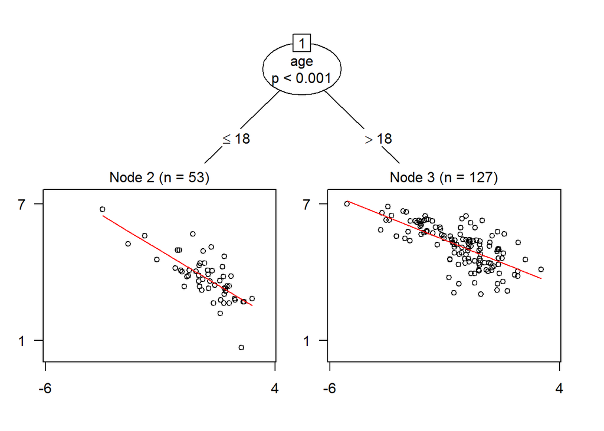

```r
tree4 <- lmtree(log(subs) ~ log(price/citations) | price + citations + age + chars + society,
                data = Journals,
                alpha = 0.85, # default significance level = 0.05
                minsize = NULL, # default: min. (10*no. of parameters) observations per node
                maxdepth = Inf, # default: Infinity
                prune = "AIC" # post-pruning based on AIC-criterion
                )
plot(tree4)
```

The result is the same as tree2.

Note that we used cross-validation in rpart for pruning and selecting the optimal subtree. Cross-validation is computationally expensive.

Here we used a different criterion, the AIC, to find an optimal subtree. The AIC is an analytical formla. It is appropriate to choose between competing linear models, but I am not sure about theory that would justify its usage in context of trees.

## What if the leaf model is not least squares regression?

Least-squares regression, logistic regression, and poisson regression regression all belong to the class of generalized linear models.

All these models can be fitted using glmtree, for example logistic regression:

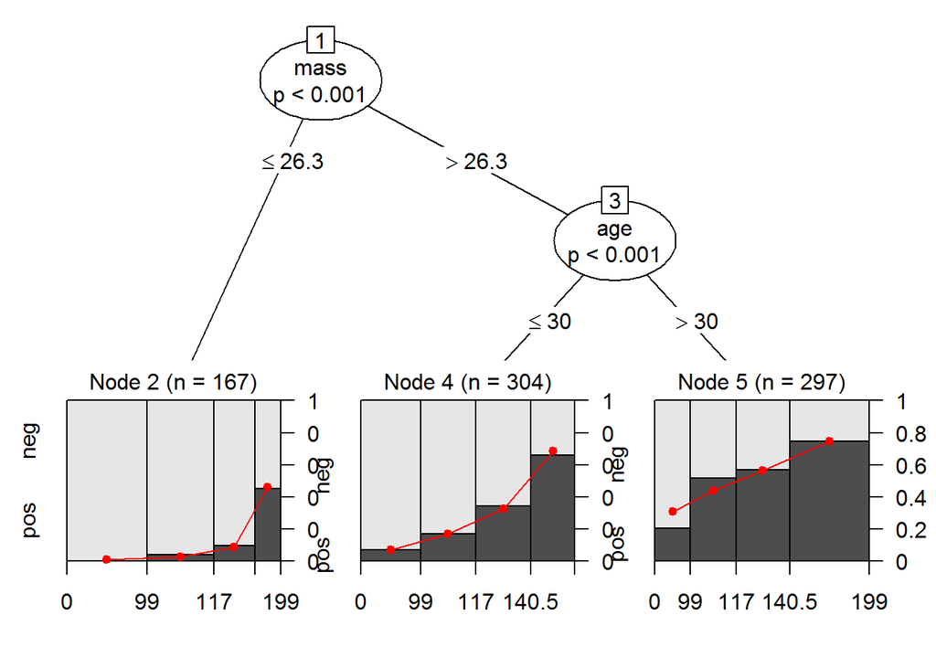

```r
data("PimaIndiansDiabetes", package = "mlbench") # load data

pid_tree1 <- glmtree(diabetes ~ glucose | pregnant + pressure + triceps + insulin + mass + pedigree + age,
                     data = PimaIndiansDiabetes,
                     family = binomial(link = "logit"), # model type: logistic regression
                     alpha = 0.05, # default significance level = 0.05
                     minsize = NULL, # default: min. (10*no. of parameters) observations per node
                     maxdepth = Inf)

plot(pid_tree1)
```

Classification tree with constant nodes and maxdepth = 3

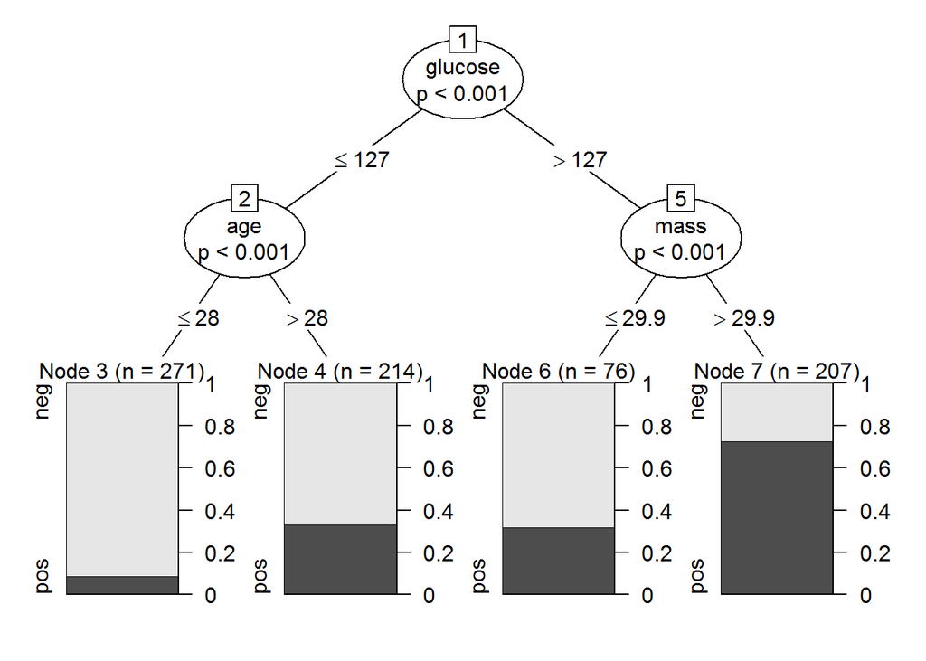

```r
pid_tree2 <- glmtree(diabetes ~ 1 | glucose + pregnant + pressure + triceps + insulin + mass + pedigree + age,
                     data = PimaIndiansDiabetes,
                     family = binomial(link = "logit"), # model type: logistic regression
                     alpha = 0.05, # default significance level = 0.05
                     minsize = NULL, # default: min. (10*no. of parameters) observations per node
                     maxdepth = 3)

plot(pid_tree2)
```

Advanced users can also implement their own model within this framework, if not available yet.

## What about missing values?

Model-based recursive partitioning (lmtree/glmtree) has no provisions for missing values. Observations with missing values are removed as a default.

Conditional inference trees (function ctree, also in the package partykit) might be an alternative if the leaves are constant. They support surrogate variables (like in rpart), but also have statistical tests implemented to choose variables to split on (like they were used above in lmtree and glmtree).

However, ctree employs a different type of tests. Unlike lmtree/glmtree, those tests are not invariant against monotone transformations of the partition variables. The following trees are therefore not identical.

```r
ctree1 <- ctree(log(subs) ~ price + citations + age + chars + society, data = Journals)
ctree2 <- ctree(log(subs) ~ log(price) + citations + age + chars + society, data = Journals)
```

## Advanced: More about parameter instability tests

How do parameter instability tests detect if $\beta$ is constant over a partitioning variable $Z_j$?

Generalized M-fluctuation tests are employed for model-based recursive partitioning. Those tests have high power in situations where $\theta$ changes abruptly (breakpoints).

The calculated p-values are then Bonferroni-adjusted to account for multiple testing of several partitioning variables. This means under the null hypothesis that $\beta = constant$ over all partitioning variables (no partition should be made), the probability to erroneously choose one variable for splitting is controlled by the significance level $\alpha$.

The theory of M-fluctuation tests is rather complicated and we only provide some intuition here. In its simplest form, it tests if the residuals from the proposed model are independent of all partitioning variables in $Z$.

Consider the a model $y = \beta_0 + \beta_1 x + \epsilon$. If optimized by least squares, the objective function is $\Psi(y, x, \beta_0, \beta_1) = (y - (\beta_0 + \beta_1 x))^2$

Its partial derivations are

$\epsilon_i := \frac{d \Psi(y_i, x_i, \beta_0, \beta_1)}{d \beta_0} = -2 (y_i - (\beta_0 + \beta_1 x_i))$ (residuals)

and

$x_i * \epsilon_i := \frac{d \Psi(y_i, x_i, \beta_0, \beta_1)}{d \beta_1} = -2 x_i (y_i - (\beta_0 + \beta_1 x))$

The test statistics is based on both/all partial derivatives of $\Psi$ and tests the null hypothesis $H_0: \beta_i = constant$ for all individuals i.

One can also plot the partial derivatives against each partitioning variable. For example, if one plots $\epsilon_i$ and $x_i * \epsilon_i$ against age, we have

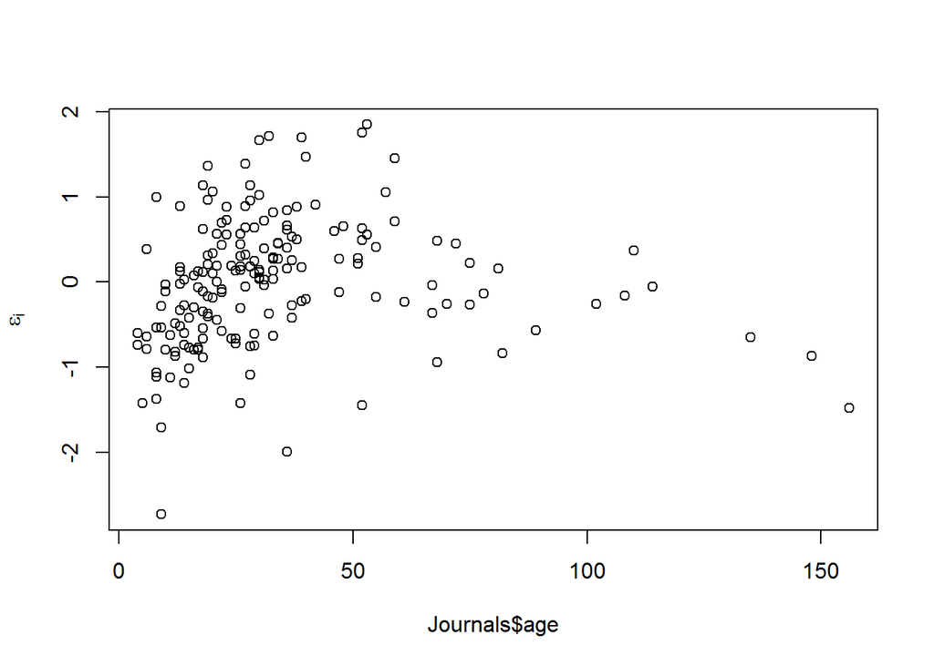

```r
m1 <- lm(log(subs) ~ log(price/citations), data = Journals)

plot(Journals$age, estfun(m1)[, 1], ylab = expression(epsilon[i]))
```

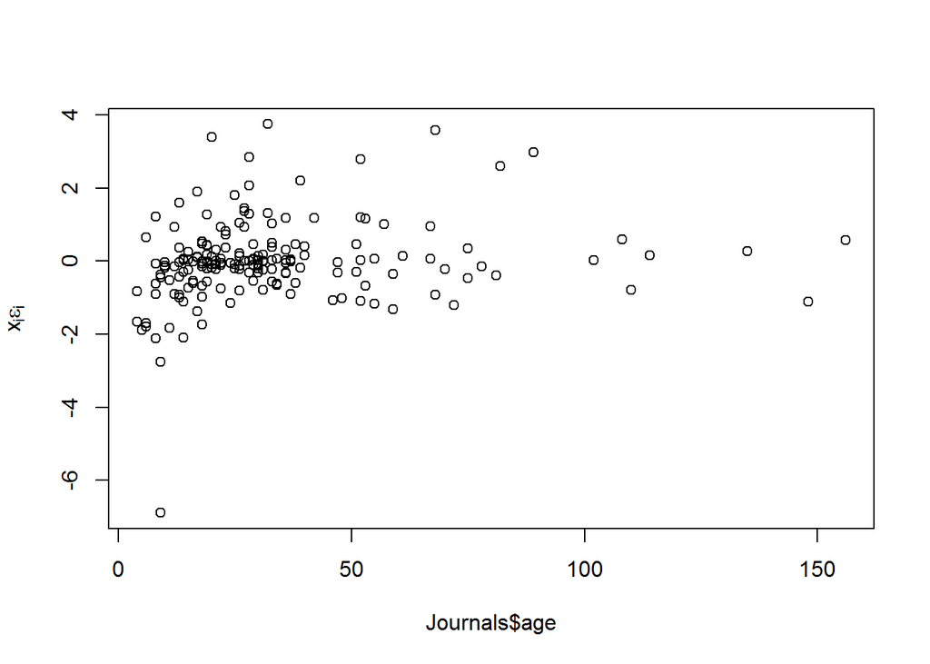

```r
plot(Journals$age, estfun(m1)[, 2], ylab = expression(x[i] * epsilon[i]))
```

If the null hypothesis were true, one would expect that $\epsilon_i$ and $x_i * \epsilon_i$ are scattered unsystematically around $0$. However, the residuals $\epsilon_i$ and $x_i * \epsilon_i$ are often smaller than $0$ for small values of age. The parameter instability test detects this and rejects the null hypothesis that $\beta = constant$ for all ages. This suggests that two models, one for small ages, and another one for high ages, might be an more appropriate model. Thus, $age \leq 18$ was the selected split point in $tree2$.

See Zeileis and Hornik (2007) for details about parameter instability tests and Seibold, Zeileis and Hothorn (2016) for a similar illustration using partial derivatives.

## References

More information about the partykit-package: https://cran.r-project.org/web/packages/partykit/ Introduction to model-based recursive partitioning: https://cran.r-project.org/web/packages/partykit/vignettes/mob.pdf